# HPC Overview

### Lecture Date: 2025-02-24

# Accessing the CPU HPC resources on JupyterHub

Note these instructions work on both [AzureAD](https://jupyterhub.cs.mtsu.edu/azuread/) and [BioSim](https://jupyterhub.cs.mtsu.edu/biosim/) even though these are different compute clusters.

Accessing the HPC login node:

```
ssh username@login.hpc.svc.cluster.local
```

Copying files from JHub onto the login node:

```
scp myfile.zip username@login.hpc.svc.cluster.local:~/myfile.zip
```

Copying files from the login node back to JHub (must use from JHub - only push/pull allowed to the login node):

```
scp username@login.hpc.svc.cluster.local:~/myfile.zip myfile.zip
```

Once logged into the system, you can check the status of the queue:

```
squeue
```

You can look for just your jobs as well. I like to use `grep` to do this (you will need to use **your username instead**) but there are other options also. Just be careful since the list often cuts off longer usernames:

```
squeue | grep jphil
```

Also, you can check the status of the queues and compute nodes overall with:

```
sinfo
```

# Running Jobs on JupyterHub HPC

Make sure your have a functioning Python script ready:

```
myscript.py
```

Create a boilerplate shell file for running the job. It should be nameed appropriately (eg. `myscript.sh`), but here are the typical contents (change the script name accordingly):

```
#!/bin/bash

srun apptainer exec /home/shared/sif/csci-2025-Spring.sif python myscript.py
```

You can then run the job by submitting it to the batch scheduler (`-c 8` requests 8 CPU cores for the job, pretty typical, but you need to set the `-t` option for time, in minutes, appropriately):

```
sbatch -c 8 -t 30 myscript.sh
```

You can use the `squeue` command above to get job numbers and check the running status. You can run `cat` or `tail` on the `slurm-N.out` files that are created for each job (where `N` is the job number provided by the scheduler).

If you need to **delete** or **cancel** a job, then use `scancel` where again `N` is the particular job number:

```
scancel N
```

Be mindful of your resource usage: we are sharing these systems and submitting long jobs or too many jobs can lock others out of using the system. Please let me know if you suspect someone might be overcommitting our resources, and I will sort it out.

# Accessing the GPU HPC resources on TAMU FASTER

Log into the web portal once you have an active ACCESS account: https://portal-faster-access.hprc.tamu.edu/

[figure not shown]

You can use the `Files` dialog to upload/download files to the cluster, but use your **SCRATCH** directory for all of your work, not your home directory (due to space limitations):

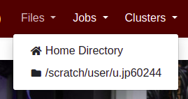

Use the `Clusters` dialog to access a shell on the login node:

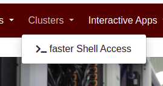

Be sure to change to your *scratch* directory for all work (there is an environment variable set for you):

```
cd ${SCRATCH}
```

Once logged into the system, you can check the status of the queue:

```
squeue
```

You can look for just your jobs as well. I like to use `grep` to do this (you will need to use **your username instead**) but there are other options also. Just be careful since the list often cuts off longer usernames:

```
squeue | grep jphil
```

Also, you can check the status of the queues and compute nodes overall with:

```
sinfo
```

TAMU FASTER also has a nice script for checking availability of the GPU resources on the system:

```
gpuavail
```

# Running Jobs on TAMU FASTER GPU HPC

Make sure your have a functioning Python script ready:

```
myscript.py
```

Create a boilerplate shell file for running the job. It should be nameed appropriately (eg. `myscript.sh`), but here are the typical contents (change the script name accordingly):

```
#!/bin/bash

srun singularity exec --nv -H ${SCRATCH} /scratch/user/u.jp60244/sif/csci-2025-Spring.sif python myscript.py
```

You can then run the job by submitting it to the batch scheduler (`--gres=gpu:t4:1` requests 1 T4 (24Gb) GPU, `--mem 32G` requests 32Gb of CPU RAM, `--ntasks 1` means you are running one task for this script, pretty typical, but you need to set the `-t` option for time, in minutes, appropriately):

```
sbatch -t 30 --gres=gpu:t4:1 --mem 32G --ntasks 1 myscript.sh
```

You can use the `squeue` command above to get job numbers and check the running status. You can run `cat` or `tail` on the `slurm-N.out` files that are created for each job (where `N` is the job number provided by the scheduler).

If you need to **delete** or **cancel** a job, then use `scancel` where again `N` is the particular job number:

```
scancel N
```

**On this system, it is normal to wait for some time before jobs run. It is a routinely used/accessed set of resources.**

Be mindful of your resource usage: we are sharing these systems and submitting long jobs or too many jobs can lock others out of using the system. Please let me know if you suspect someone might be overcommitting our resources. I can try to coordinate with the systems administrators if there are persistent issues.

Remember, this system is shared by **many** users and they will sometimes commit **weeks** to running certain project scripts. Since we are just using T4 resources, this isn't typically a problem, but sometimes it can happen. Some labs will require planning ahead by 10-12 hours to get jobs to run - be careful to perform plenty of short debugging runs on JHub **before** moving onto TAMU FASTER.